# Taller 2 Regresión

## 1. Ajuste de modelo de regresión lineal múltiple

Considere las siguientes variables:

$Y_i:$ i-ésima observación de la variable respuesta ‘Longitud de permanencia’ (DPERM).  
$X_{i1}:$ i-ésima observación de la variable predictoria ‘Edad’ (EDAD).  
$X_{i2}:$ i-ésima observación de la variable predictoria ‘Riesgo de infección’ (RINF).  
$X_{i3}:$ i-ésima observación de la variable predictoria ‘Razón de rutina de cultivos’ (RRC).  
$X_{i4}:$ i-ésima observación de la variable predictoria ‘Razón de rutina de rayos X del pecho’ (RRX).  
$X_{i5}:$ i-ésima observación de la variable predictoria ‘Número de camas’ (NCAMAS).  
$X_{i6}:$ i-ésima observación de la variable predictoria ‘Censo promedio diario’ (PDP).  
$X_{i7}:$ i-ésima observación de la variable predictoria ‘Número de enfermeras’ (NENFERM).  
$X_{i8}:$ i-ésima observación de la variable predictoria ‘Facilidades y servicios disponibles’ (FSD).

Se observa que se tienen 90 observaciones y k= 8 variables regresoras.

Se asume que el modelo de regresión lineal múltiple tiene la siguiente forma:
$$Y_i = \beta_0 + \beta_1 X_{i1}+ \beta_2 X_{i2}+ \beta_3 X_{i3}+ \beta_4 X_{i4}+ \beta_5 X_{i5}+ \beta_6 X_{i6}+ \beta_7 X_{i7}+ \beta_8 X_{i8} + E_i \ ,
\ E_i\overset{iid}{\sim}\mathcal{N}(0, \sigma^2), i=1,...,90$$

Se ajusta un modelo de regresión lineal multiple:

Se escribe la ecuación ajustada:

$\hat{Y_i}=-0.2084+0.1043X1+0.3352X2+0.0287X3+0.0209X4-0.0106X5+0.0223X6-0.006X7+0.0041X8, i=1,...,90.$

Se muestra la tabla de parámetros ajustados:

```r
kable(summary(modelo1)$coefficients)
```

|  | Estimate | Std. Error | t value | Pr(>\|t\|) |
| --- | --- | --- | --- | --- |
| (Intercept) | -0.2084670 | 1.9450831 | -0.1071764 | 0.9149141 |
| EDAD | 0.1043806 | 0.0340139 | 3.0687638 | 0.0029235 |
| RINF | 0.3352223 | 0.1555968 | 2.1544291 | 0.0341775 |
| RRC | 0.0287063 | 0.0177746 | 1.6150188 | 0.1101955 |
| RRX | 0.0209817 | 0.0085074 | 2.4662932 | 0.0157625 |
| NCAMAS | -0.0106992 | 0.0044559 | -2.4011396 | 0.0186350 |
| PDP | 0.0223642 | 0.0048806 | 4.5822850 | 0.0000165 |
| NENFERM | -0.0060256 | 0.0029319 | -2.0552029 | 0.0430819 |
| FSD | 0.0041605 | 0.0195476 | 0.2128384 | 0.8319878 |

Se calcula la tabla ANOVA del modelo:

```r
kable(myAnova(modelo1))
```

|  | Sum_of_Squares | DF | Mean_Square | F_Value | P_value |
| --- | --- | --- | --- | --- | --- |
| Model | 217.568 | 8 | 27.19606 | 14.6536 | 5.0418e-13 |
| Error | 150.330 | 81 | 1.85592 |  |  |

Con un p-value casi igual a cero, se concluye que al menos una de las covariable es significativa para explicar la variabilidad de la longitud de permanencia.

Del resumen del modelo se obtiene que el valor de $R^2$ es 0.5914, es decir que un 59.14% de la variabilidad total de la longitud de permanencia es explicada por el modelo. Se opina que este porcentaje de la variabilidad tan “bajo” puede deberse a que alguna de las covariables no sea significativa, o no es adecuado suponer que existe una relación lineal entre la longitud de permanencia y las covariables númericas presentándose carencia de ajuste.

## 2. Coeficientes estandarizados:

Se calculan los coeficientes de un modelo de regresión lineal multiple con las variables estándarizadas, ordenados de menor a mayor:

Tabla de coeficientes Estandarizados

|  | Coef.Std |
| --- | --- |
| FSD | 0.0275649 |
| RRC | 0.1514452 |
| RRX | 0.2074015 |
| RINF | 0.2254678 |
| EDAD | 0.2354129 |
| NENFERM | 0.3839389 |
| NCAMAS | 0.9777531 |
| PDP | 1.6801779 |

De la tabla se concluye que la covariable que “más” aporta al modelo cuando los datos se encuentran estándarizados es el “Censo promedio diario”, indicando que un aumento unitario en el “Censo promedio diario” estándarizado aumentaría en $1.68$ unidades en promedio la longitud de permanencia estándarizada, dado que el resto de covariables están en el modelo.

Además del “Censo promedio diario”, se encontró que dos de las covariables que estándarizadas más aportan al modelo son el número de camas y el número de enfermeras, sugiriendo que las primeras tres covariables que estandarizadas más aportan al modelo se relacionan con el tamaño de los hospitales.

## 3. Significancia individual de los parámetros del modelo:

Cada una de las pruebas t para la significancia individual de los parámetros del modelo tienen la siguiente forma:

$$H_0: \beta_j = 0\ \ vs.\ \ H_1:\beta_j \neq 0\ , j = 1,...,8.$$
$$T_{0j}= \frac{\widehat{\beta_j}}{s.e(\widehat{\beta_j})} \sim t_{81}\ , j = 1,...,8.$$
$$p \textrm{-} value_j = P(|t_{81}| > \lvert T_{0j} \rvert).$$
Se crea una tabla de coeficientes asociados a cada covariable, que incluye el valor de su estadístico t y el valor p de su prueba de hipótesis.

|  | Estimación | Estadístico t | Valor p |
| --- | --- | --- | --- |
| EDAD | 0.1043806 | 3.0687638 | 0.0029235 |
| RINF | 0.3352223 | 2.1544291 | 0.0341775 |
| RRC | 0.0287063 | 1.6150188 | 0.1101955 |
| RRX | 0.0209817 | 2.4662932 | 0.0157625 |
| NCAMAS | -0.0106992 | -2.4011396 | 0.0186350 |
| PDP | 0.0223642 | 4.5822850 | 0.0000165 |
| NENFERM | -0.0060256 | -2.0552029 | 0.0430819 |
| FSD | 0.0041605 | 0.2128384 | 0.8319878 |

Cálculo de valor p:
$$p\text{-}value = P(f_{1, 81} > F_{06})$$

| Res.Df | RSS | Df | Sum of Sq | F | Pr(>F) |
| --- | --- | --- | --- | --- | --- |
| 82 | 189.2993 |  |  |  |  |
| 81 | 150.3299 | 1 | 38.9694680543685 | 20.9973358998904 | 1.6484475391443e-05 |

La tabla anterior nos brinda todo lo necesario para construir nuestro estadítico de prueba $F_{06}$.
$$g.l.(SSE(X_1,X_2,X_3,X_4,X_5,X_7,X_8)) = 82$$
$$g.l.(SSE(X_1,X_2,X_3,X_4,X_5,X_6,X_7,X_8)) = 81$$
$$SSE(X_1,X_2,X_3,X_4,X_5,X_7,X_8) = 189.30$$
$$SSE(X_1,X_2,X_3,X_4,X_5,X_6,X_7,X_8) = 150.33$$
$$g.l(SSR(X_6|X_1,X_2,X_3,X_4,X_5,X_7,X_8)) = 82-81=1$$
$$SSR(X_6|X_1,X_2,X_3,X_4,X_5,X_7,X_8) = 189.30-150.33 = 38.969$$

La columna ‘F’ presenta el valor de $F_{06}$ y la columna Pr(>F) su respectivo p-value.

- **Prueba F para test lineal general de la variable EDAD**

Modelo completo:  
$Y_i = \beta_0 + \beta_1 X_{i1}+ \beta_2 X_{i2}+ \beta_3 X_{i3}+ \beta_4 X_{i4}+ \beta_5 X_{i5}+ \beta_6 X_{i6}+ \beta_7 X_{i7}+ \beta_8 X_{i8} + E_i \ ,\ E_i\overset{iid}{\sim}\mathcal{N}(0, \sigma^2)$

Modelo reducido:  
$Y_i = \beta_0 + \beta_2 X_{i2}+ \beta_3 X_{i3}+ \beta_4 X_{i4}+ \beta_5 X_{i5}+ \beta_6 X_{i6}+ \beta_7 X_{i7}+ \beta_8 X_{i8} + E_i \ ,\ E_i\overset{iid}{\sim}\mathcal{N}(0, \sigma^2)$

Estadístico de prueba y distribución:
$$\begin{gather}
F_{01} = \frac{SSR(X_1|X_2,X_3,X_4,X_5,X_6,X_7,X_8)}
{MSE(X_1,X_2,X_3,X_4,X_5,X_6,X_7,X_8)}\ , \\
F_{01} = \frac{SSE(X_2,X_3,X_4,X_5,X_6,X_7,X_8) - SSE(X_1,X_2,X_3,X_4,X_5,X_6,X_7,X_8)}
{MSE(X_1,X_2,X_3,X_4,X_5,X_6,X_7,X_8)}\ , \\
F_{01} \sim f_{1, 81}
\end{gather}$$

Cálculo de valor p:
$$p\text{-}value = P(f_{1, 81} > F_{01})$$

```r
lh2 <- linearHypothesis(modelo1, "EDAD = 0")
lh2[1, 3:6] <- c(" ", " ", " ", " ")
kable(lh2)
```

| Res.Df | RSS | Df | Sum of Sq | F | Pr(>F) |
| --- | --- | --- | --- | --- | --- |
| 82 | 167.8077 |  |  |  |  |
| 81 | 150.3299 | 1 | 17.4778182328601 | 9.41731151476297 | 0.00292351905114798 |

## Sumas de cuadrados de tipo 1 y de tipo 2:

### Sumas de cuadrados de tipo 1:

```r
kable(anova(modelo1)[1:2])
```

|  | Df | Sum Sq |
| --- | --- | --- |
| EDAD | 1 | 13.2851764 |
| RINF | 1 | 116.2244592 |
| RRC | 1 | 1.9362640 |
| RRX | 1 | 8.4433232 |
| NCAMAS | 1 | 31.8519622 |
| PDP | 1 | 37.8732896 |
| NENFERM | 1 | 7.8699352 |
| FSD | 1 | 0.0840737 |
| Residuals | 81 | 150.3298765 |

### Sumas de cuadrados de tipo II:

```r
kable(Anova(modelo1)[1:2])
```

|  | Sum Sq | Df |
| --- | --- | --- |
| EDAD | 17.4778182 | 1 |
| RINF | 8.6143936 | 1 |
| RRC | 4.8407814 | 1 |
| RRX | 11.2888497 | 1 |
| NCAMAS | 10.7002791 | 1 |
| PDP | 38.9694681 | 1 |
| NENFERM | 7.8391631 | 1 |
| FSD | 0.0840737 | 1 |
| Residuals | 150.3298765 | 81 |

## 5.Gráfico de residuales estudentizados vs Valores ajustados

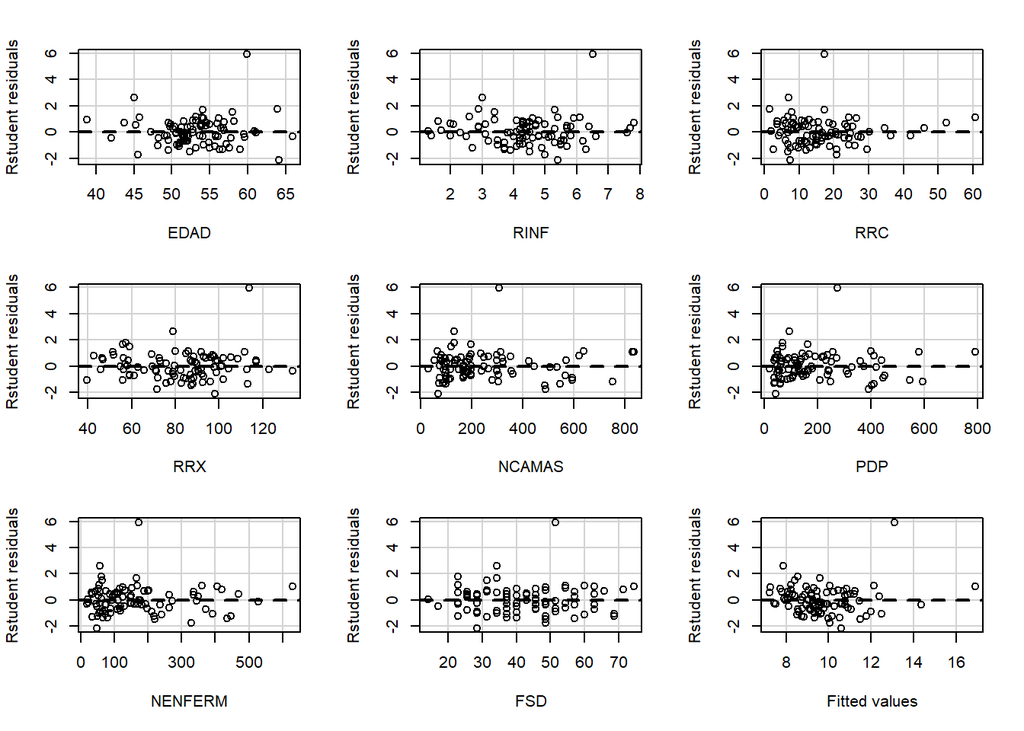

```r
residualPlots(modelo1, type = "rstudent", tests = FALSE, quadratic = FALSE, fit = TRUE)
```

## Gráfica de probabilidad normal para los residuales estudentizados.

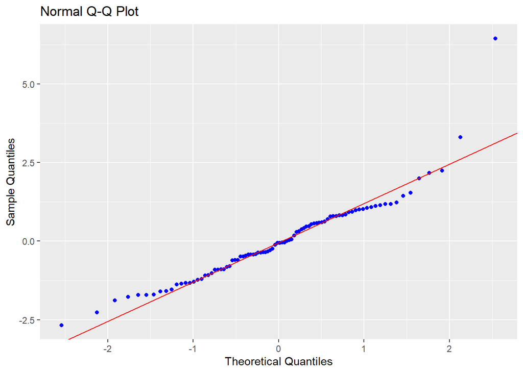

```r
ols_plot_resid_qq(model = modelo1)
```

```r
normalidad <- shapiro.test(modelo1$residuals)
kable(t(normalidad[c("p.value" ,"statistic" )]))
```

| p.value | statistic |
| --- | --- |
| 1.83204082572401e-05 | c(W = 0.914090225195161) |

Según la gráfica anterior se observa un desajuste al inicio y al final de la gráfica que permite dudar sobre la hipótesis de normalidad sobre los errores del modelo.

## 7. Diagnóstico de la presencia de observaciones atípicas, de balanceo y/o influenciales.

Se crea una tabla con las medidas de influencia:

```r
influencias_modelo1 <- influence.measures(modelo1)
influencias_modelo1 <- (influencias_modelo1$infmat)
influencias_modelo1 <- cbind(influencias_modelo1, std.res = rstandard(modelo1), stud.res = rstudent(modelo1))
```

### Observaciones atípicas mediante residuales estándarizados:

```r
which(abs(influencias_modelo1[,"std.res"])>3 )
```

```
## 22
## 22
```

Según los residuales estándarizados la observación 22 es una observación atípica potencial.

### Observaciones atípicas mediante residuales estudentizados:

```r
which(abs(influencias_modelo1[,"stud.res"])>3 )
```

```
## 22
## 22
```

De nuevo se observa que según los residuales estudentizados la observación 22 es una observación potencialmente atípica.

### Observaciones influyentes según las distancias de cook:

```r
which(influencias_modelo1[,"cook.d"] > 1)
```

```
## named integer(0)
```

Según el criterio de las distancias de cook no se tienen observaciones influyentes.

### Observaciones influyentes según los DFBetas:

Según el criterio de los DFBetas las siguientes observaciones son influyentes:

```r
influencias_modelo1 <- as.data.frame(influencias_modelo1)
influenciales_dfbetas <- which(abs(influencias_modelo1[,1:9])> (2/sqrt(90)),arr.ind = TRUE)
kable(influencias_modelo1[unique(influenciales_dfbetas[, "row"]), 1:9])
```

|  | dfb.1_ | dfb.EDAD | dfb.RINF | dfb.RRC | dfb.RRX | dfb.NCAM | dfb.PDP | dfb.NENF | dfb.FSD |
| --- | --- | --- | --- | --- | --- | --- | --- | --- | --- |
| 22 | -1.0554668 | 0.7022585 | 0.5998931 | -0.3475937 | 0.6269032 | -0.5409321 | 0.7018199 | -0.4175396 | 0.3460527 |
| 40 | 0.3320045 | -0.3901691 | -0.0255484 | -0.1062093 | 0.0613822 | 0.1202810 | -0.1114995 | -0.1478821 | 0.1495173 |
| 55 | 0.6421624 | -0.6371584 | -0.0369117 | -0.2969916 | 0.0901574 | 0.0267936 | 0.0429387 | -0.2630476 | 0.0648500 |
| 60 | -0.3328238 | 0.2870884 | -0.0651160 | 0.0145697 | 0.1170199 | -0.0072072 | -0.0690868 | -0.0210495 | 0.1690624 |
| 74 | -0.2495917 | 0.4418508 | -0.0371980 | -0.0448277 | -0.1013220 | 0.1996062 | -0.1651794 | 0.0527205 | -0.3295966 |
| 85 | 0.4375781 | -0.4511554 | -0.3196276 | 0.2715474 | -0.1446658 | -0.0217175 | 0.0825145 | -0.1123090 | 0.2150019 |
| 9 | 0.0902519 | 0.0177271 | 0.2902498 | -0.0207575 | -0.3626614 | -0.1687336 | 0.1217437 | 0.1375595 | -0.1363087 |
| 25 | -0.0078033 | 0.0007032 | -0.3519338 | 0.7141728 | -0.0278419 | 0.6263768 | -0.5035366 | -0.2313406 | -0.0308203 |
| 29 | -0.0113679 | 0.0610503 | 0.2457186 | 0.1203398 | -0.4100964 | -0.0987417 | 0.1201803 | -0.2702677 | 0.1256884 |
| 23 | -0.0984735 | 0.1479445 | -0.1734543 | 0.2292467 | 0.0331173 | -0.3012805 | 0.6778416 | -0.3740053 | -0.1557559 |
| 36 | -0.0849350 | 0.0652693 | -0.0762586 | -0.0385920 | 0.2541075 | 0.3099330 | -0.3642124 | 0.0389461 | -0.1382575 |
| 78 | 0.0207676 | -0.0462453 | -0.0644256 | 0.0000631 | 0.2943916 | 0.1226837 | -0.0165751 | -0.0929246 | -0.2559914 |
| 32 | 0.0239483 | -0.0381453 | -0.0773553 | 0.0527249 | 0.0317064 | -0.2471923 | 0.0676942 | 0.3188200 | 0.0948138 |
| 83 | -0.0500643 | 0.0882718 | -0.0370633 | -0.0714219 | -0.0857580 | 0.2775600 | -0.3307215 | 0.2834297 | -0.0971331 |
| 62 | -0.0984058 | 0.0983355 | 0.0042810 | 0.1604606 | -0.1181551 | -0.0814065 | -0.1199827 | 0.2856051 | 0.1011190 |

### Observaciones influenciales según los DFFITS:

Según los dffits se tiene que las siguientes observaciones son influenciales:

```r
influencias_dffits <- which(abs(influencias_modelo1[, "dffit"])>(2*(sqrt(9/90))))
kable(cbind(influencias_dffits,influencias_modelo1[ influencias_dffits,c("dffit")]))
```

| influencias_dffits |  |
| --- | --- |
| 22 | 1.9386575 |
| 23 | 0.9924519 |
| 25 | 1.0390092 |
| 55 | 0.7983544 |
| 74 | 0.6795084 |
| 83 | 0.6484951 |
| 85 | -0.7875551 |

### Puntos influencciales según el COVRATIO:

Se verifica que $90>3(9)$, luego se puede concluir que una observación será cabdudata a ser influencial sí $|COVRATIO_i-1|>\frac{3(9)}{90}$, así, las siguientes observaciones son candidatas a ser influenciales:

```r
influenciales_covratio <- which(abs(influencias_modelo1[, "cov.r"] -1)> (3*9/90))
kable(covratio(modelo1)[influenciales_covratio])
```

|  | x |
| --- | --- |
| 3 | 1.3957971 |
| 14 | 1.5313864 |
| 21 | 1.4263831 |
| 22 | 0.0461483 |
| 23 | 1.8486647 |
| 25 | 1.8114627 |
| 34 | 1.3678717 |
| 48 | 1.3047817 |
| 52 | 1.3174769 |
| 55 | 0.5788661 |
| 58 | 1.5531299 |
| 76 | 1.3103089 |
| 83 | 1.3591291 |

```r
datos2 <- datos[-c(22,23),]
modelo2 <- lm(rlm_formula, data = datos2)
```

Se presenta la tabla de parámetros ajustados:

```r
kable(summary(modelo2)$coefficients)
```

|  | Estimate | Std. Error | t value | Pr(>\|t\|) |
| --- | --- | --- | --- | --- |
| (Intercept) | 1.9108818 | 1.6315588 | 1.1712001 | 0.2450388 |
| EDAD | 0.0750774 | 0.0284371 | 2.6401247 | 0.0099832 |
| RINF | 0.2979983 | 0.1297458 | 2.2967863 | 0.0242799 |
| RRC | 0.0273794 | 0.0149250 | 1.8344692 | 0.0703492 |
| RRX | 0.0158335 | 0.0070254 | 2.2537458 | 0.0269836 |
| NCAMAS | -0.0063596 | 0.0038298 | -1.6605654 | 0.1007650 |
| PDP | 0.0138772 | 0.0048219 | 2.8779749 | 0.0051460 |
| NENFERM | -0.0031345 | 0.0025662 | -1.2214791 | 0.2255373 |
| FSD | 0.0032664 | 0.0162206 | 0.2013754 | 0.8409227 |

### Gráfico de normalidad para los residuales estudentiszados:

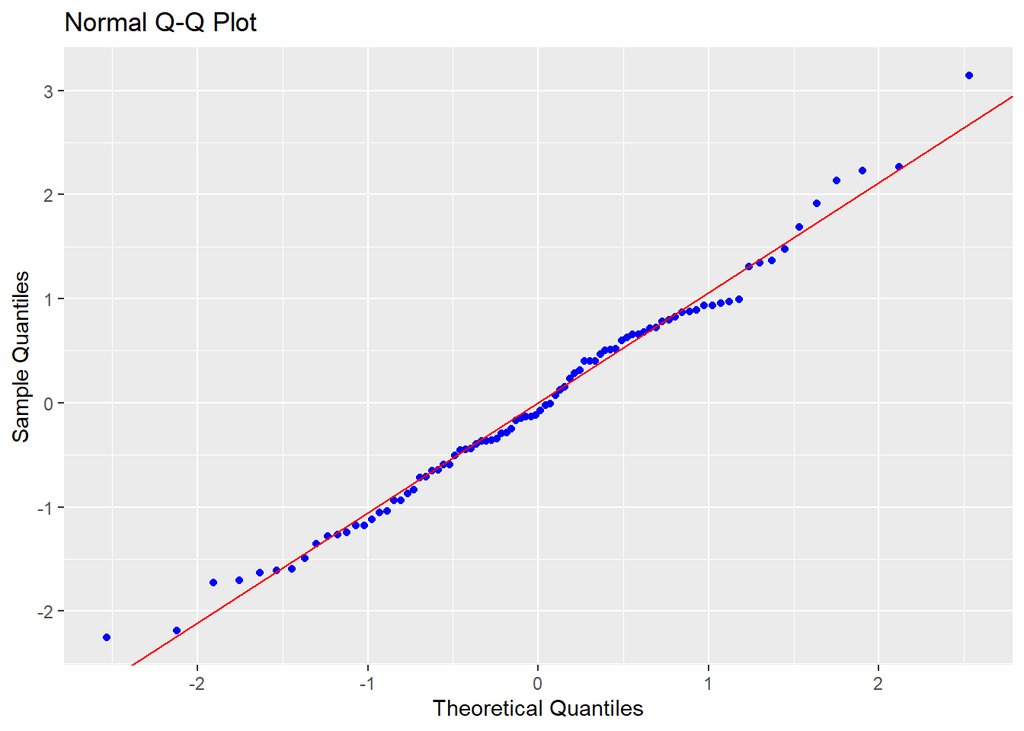

```r
ols_plot_resid_qq(model = modelo2)
```

Se observa una notoria mejoría en la gráfica de normalidad de los residuales estudentizados respecto a la gráfica anterior.

## 8. Diagnósticos de multicolinealidad:

### Diagnósticos de multicolinealidad mediante la Matriz de correlación de las variables predictoras:

```r
kable(cor(datos2[ , numericas]))
```

|  | DPERM | EDAD | RINF | RRC | RRX | NCAMAS | PDP | NENFERM | FSD |
| --- | --- | --- | --- | --- | --- | --- | --- | --- | --- |
| DPERM | 1.0000000 | 0.1096885 | 0.5889121 | 0.3658230 | 0.3924108 | 0.3894938 | 0.4253582 | 0.3584809 | 0.3764379 |
| EDAD | 0.1096885 | 1.0000000 | -0.0384364 | -0.2861650 | -0.0734373 | -0.1203036 | -0.1286958 | -0.1571305 | -0.0585730 |
| RINF | 0.5889121 | -0.0384364 | 1.0000000 | 0.5583204 | 0.4403791 | 0.4039787 | 0.4104520 | 0.4019360 | 0.4012267 |
| RRC | 0.3658230 | -0.2861650 | 0.5583204 | 1.0000000 | 0.3990202 | 0.1006151 | 0.0902737 | 0.1519585 | 0.1034185 |
| RRX | 0.3924108 | -0.0734373 | 0.4403791 | 0.3990202 | 1.0000000 | -0.0210621 | -0.0063915 | 0.0163626 | 0.0594719 |
| NCAMAS | 0.3894938 | -0.1203036 | 0.4039787 | 0.1006151 | -0.0210621 | 1.0000000 | 0.9825362 | 0.9228352 | 0.8227744 |
| PDP | 0.4253582 | -0.1286958 | 0.4104520 | 0.0902737 | -0.0063915 | 0.9825362 | 1.0000000 | 0.9231892 | 0.8152669 |
| NENFERM | 0.3584809 | -0.1571305 | 0.4019360 | 0.1519585 | 0.0163626 | 0.9228352 | 0.9231892 | 1.0000000 | 0.7958386 |
| FSD | 0.3764379 | -0.0585730 | 0.4012267 | 0.1034185 | 0.0594719 | 0.8227744 | 0.8152669 | 0.7958386 | 1.0000000 |

### Diagnósticos de multicolinealidad mediante los VIF’s:

```r
kable(t(vif(modelo2)))
```

| EDAD | RINF | RRC | RRX | NCAMAS | PDP | NENFERM | FSD |
| --- | --- | --- | --- | --- | --- | --- | --- |
| 1.176584 | 2.151059 | 1.806731 | 1.376914 | 31.91805 | 31.61002 | 7.564419 | 3.290859 |

### Diagnósticos de multicolinealidad mediante las proporciones de varianza:

```r
ols_coll_diag(modelo2)
```

```
## Tolerance and Variance Inflation Factor
## ---------------------------------------
##   Variables  Tolerance       VIF
## 1      EDAD 0.84991789  1.176584
## 2      RINF 0.46488734  2.151059
## 3       RRC 0.55348588  1.806731
## 4       RRX 0.72626193  1.376914
## 5    NCAMAS 0.03133024 31.918049
## 6       PDP 0.03163553 31.610025
## 7   NENFERM 0.13219787  7.564419
## 8       FSD 0.30387208  3.290858
##
##
## Eigenvalue and Condition Index
## ------------------------------
```

[output cut: 20 more lines]

## 9. Selección de modelo:

### Tabla de todas las regresiones posibles:

```r
regresiones  <- ols_step_all_possible(modelo2)
```

```r
head(regresiones)
```

```
##   Index N Predictors  R-Square Adj. R-Square Mallow's Cp
## 2     1 1       RINF 0.3468174     0.3392223    20.46379
## 6     2 1        PDP 0.1809296     0.1714055    46.99431
## 4     3 1        RRX 0.1539862     0.1441489    51.30337
## 5     4 1     NCAMAS 0.1517054     0.1418415    51.66814
## 8     5 1        FSD 0.1417055     0.1317253    53.26743
## 3     6 1        RRC 0.1338265     0.1237547    54.52753
```